# Summary of FLASH2 outputs

Jim Zhang

2018-10-15

**Introduction** This analysis compares a set of paired end **FASTQ** files processed by the **FLASH2** program, which combines pairs of overlapping reads to generate longer, single-end reads. **Flash2** processes read pairs based on the following 3 scenarios:

- Non-overlapping. When the DNA fragments are longer than 2 times of the read length, the paired reads have no overlapping. Therefore, the paired reads will be written separately into 2 fastq files, just like the way they were saved in the original pair of fastq files.
- Innie merging. When the DNA fragments are longer than the read length, but shorter than 2 times of the read length, the paired reads are partially overlapped. The paired reads are merged into a longer read and saved to a different fastq file as a single-ended read. The new read includes the full sequences of both reads, with more or less overlapping in th middle. If the reads disagree on the overlapping sequence, the base call with higher quality score will be used.
- Outie merging. When the DNA fragments are short than the read length, the paired reads both sequenced the fragment and overlap to each other at the beginning of both reads. The overlapping part will be saved as a short, single-ended read in the same fastq file of the innie merging reads. The non-overlapping parts of the reads, including all or part of the adaptors, will be discarded. The disagreement within the overlapping sequence will also be determined by base call quality.

*[Go to project home](http://zhezhangsh.github.io/RoCA)*

# 1 Description

## 1.1 Project

PRO-seq project

## 1.2 Analysis

FASTQ files of 16 PRO-seq libraries

*[Go to project home](http://zhezhangsh.github.io/RoCA)*

# 2 Results

## 2.1 Summary of read count

Total number of reads in different categories according to **FLASH2**.

> Click here to view summary table.

**Table 1.** Percentages of read pairs in each **FLASH2** category. “*Combined*” equals to the sum of *Innie* and *Outie*.

|  | Total | Discarded(%) | Combined(%) | Innie(%) | Outie(%) | Uncombined(%) |
| --- | --- | --- | --- | --- | --- | --- |
| 1501 | 251532955 | 0.0000 | 86.8824 | 14.9425 | 71.9399 | 13.1176 |
| 1502 | 265217274 | 0.0000 | 84.0776 | 14.6011 | 69.4764 | 15.9224 |
| 1662 | 250176872 | 0.0000 | 83.7626 | 15.3823 | 68.3803 | 16.2374 |
| 1663 | 339852023 | 0.0000 | 76.2419 | 12.8144 | 63.4275 | 23.7581 |
| 1664 | 163419734 | 0.0035 | 83.0023 | 9.1835 | 73.8188 | 16.9942 |
| 1665 | 168854587 | 0.0036 | 83.1048 | 9.6775 | 73.4273 | 16.8916 |
| 1666 | 122163247 | 0.0036 | 83.6945 | 11.2540 | 72.4404 | 16.3019 |
| 1667 | 121758864 | 0.0035 | 84.2893 | 8.4905 | 75.7988 | 15.7072 |
| 1696 | 131335736 | 0.0000 | 82.5836 | 20.1907 | 62.3929 | 17.4164 |
| 1697 | 97979783 | 0.0000 | 81.4929 | 11.6126 | 69.8803 | 18.5071 |
| 1698 | 112550728 | 0.0000 | 77.7007 | 14.6833 | 63.0174 | 22.2993 |
| 1699 | 134887552 | 0.0000 | 83.7933 | 14.2287 | 69.5646 | 16.2067 |
| 1864 | 462304566 | 0.0004 | 75.8410 | 29.4268 | 46.4142 | 24.1586 |
| 1865 | 465041946 | 0.0008 | 75.7214 | 29.5017 | 46.2197 | 24.2779 |
| 1866 | 467777889 | 0.0001 | 59.3598 | 35.5292 | 23.8306 | 40.6401 |
| 1867 | 379659795 | 0.0007 | 66.7171 | 33.5676 | 33.1495 | 33.2822 |

## 2.2 Summary of read length

Length of single end reads generated by **FLASH2**, subtracting the 6 base(s) of barcode.

> Click here to view read counts by length table.

> Click here to view read percentages by length table.

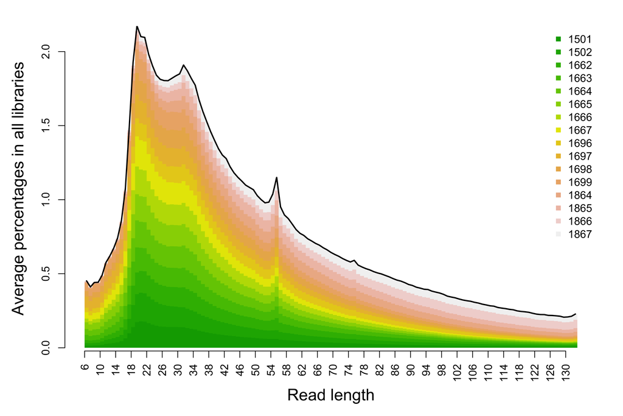

**Figure 1.** Average percentages of reads with given length among all merged reads.

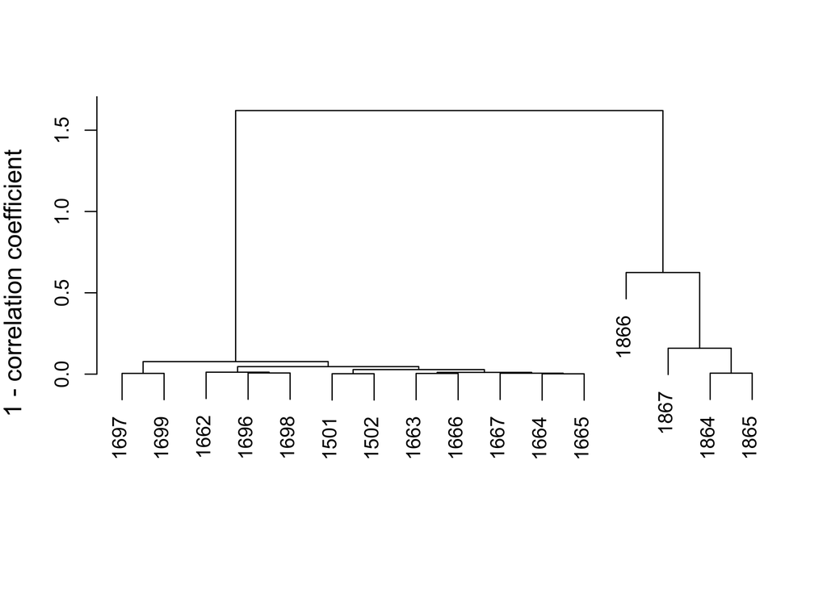

**Figure 2.** Similarity of read length distribution.

*[Go to project home](http://zhezhangsh.github.io/RoCA)*

*END OF DOCUMENT*